# R Notebook

### - *Percepción sobre el cambio de alimentación por el confinamiento:*

### **Análisis univariado:**

##### En esta variable se analizo la percepcion sobre el cambio de alimentacion de los estudiantes de UTEC por el confinamiento, donde se obtuvo los siguientes resultados:

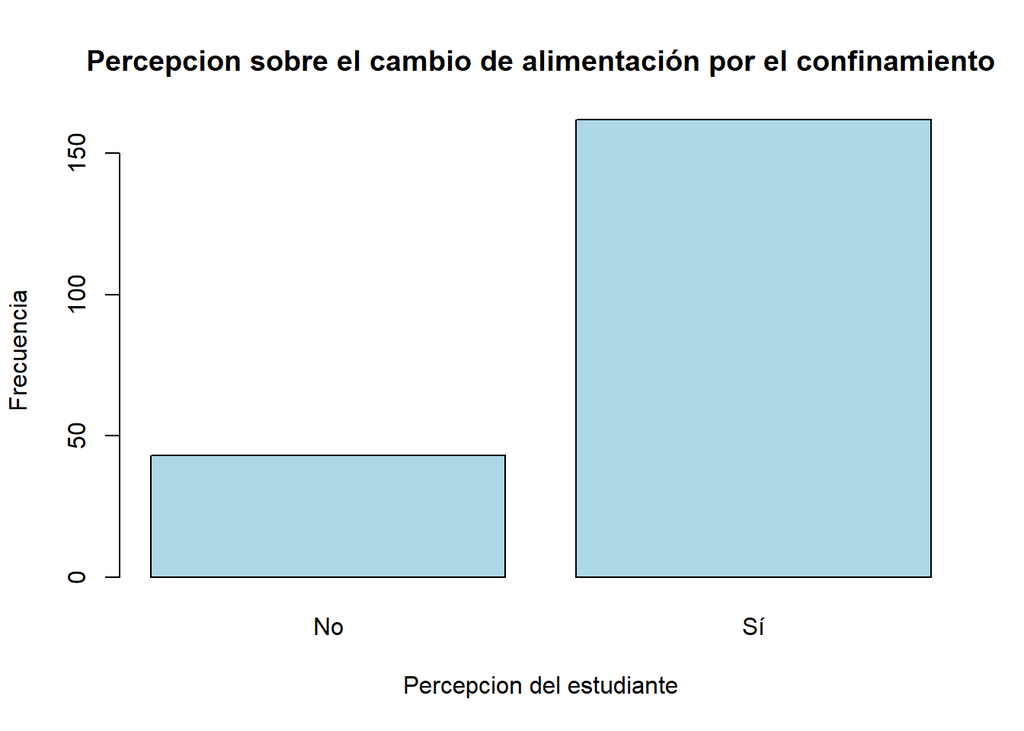

```r
TABLA<-table(BD$`Percepción sobre el cambio de alimentación por el confinamiento`)
barplot(TABLA, main = "Percepcion sobre el cambio de alimentación por el confinamiento",
     xlab = "Percepcion del estudiante", ylab = "Frecuencia",
     col = c("lightblue"))
```

##### De este grafico podemos afirmar que los alumnos de la Universidad de Ingenieria y Tecnologia perciben que su habito alimenticio que mantenian ha cambiado producto del confinamiento.

```r
cat('Número de observaciones:', nrow(BD),'\n')
```

```
## Número de observaciones: 205
```

```r
cat('Número de casos completos de la variable de percepción del cambio de alimentacion por el confinamiento :', sum(complete.cases(BD$`Percepción sobre el cambio de alimentación por el confinamiento`)),'\n')
```

```
## Número de casos completos de la variable de percepción del cambio de alimentacion por el confinamiento : 205
```

##### El número de observaciones y el numero de casos completos para la variable de percepción del cambio de alimentacion por el confinamiento es 205, por lo que la muestra selectiva para el análisis de esta variable es 205 observaciones.

```r
cat('Moda de la variable de percepción del cambio de alimentacion por el confinamiento:', "Si" ,'\n')
```

```
## Moda de la variable de percepción del cambio de alimentacion por el confinamiento: Si
```

##### Esta variable es de tipo cualitativa por lo que se determina la moda obteniendose que los estudiantes de UTEC perciben que el habito alimenticio que mantenian ha cambiado por el confinamiento, por lo que se podría decir que este influyó en la alimentación de los estudiantes de UTEC.

### - *Causas del cambio de alimentación durante el confinamiento:*

### **Análisis univariado:**

##### En esta variable se analizaron las causas del cambio de alimentacion durante el confinamiento en los estudiantes de UTEC, donde se obtuvo los siguientes resultados:

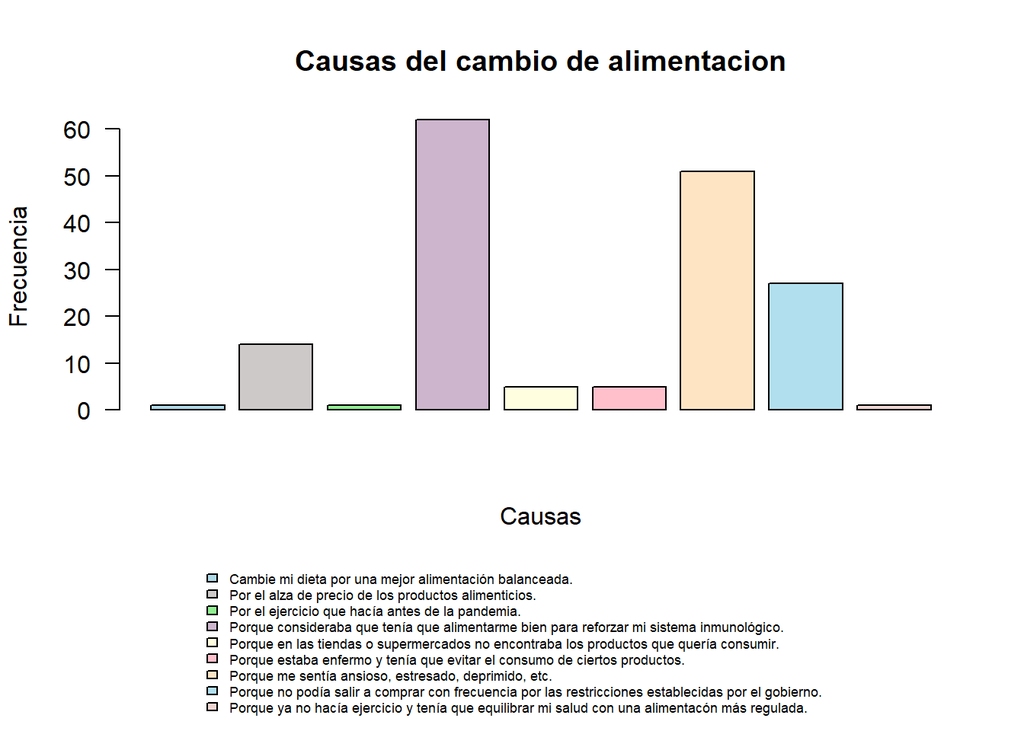

```r
layout(rbind(1, 2), heights = c(10, 3))
counts <- table(BD$`Causas del cambio de alimentación durante el confinamiento`)
barplot(counts,xaxt = "n", main="Causas del cambio de alimentacion",  xlab = "Causas", ylab = "Frecuencia",
        col=c("lightblue", "snow3","lightgreen","thistle3","lightyellow","pink", "bisque","lightblue2","mistyrose2"), las=2,cex.names = 0.45)
par(mar = c(0, 0, 0, 0))
plot.new()
legend('top', legend=rownames(counts), bty='n',
       fill=c("lightblue", "snow3","lightgreen","thistle3","lightyellow","pink", "bisque","lightblue2","mistyrose2"),cex = 0.55)
```

##### De este grafico podemos afirmar que la causa principal del cambio de alimentacion en los estudiantes de la Universidad de Ingenieria y Tecnologia, fue por el motivo de que consideraban adquirir un habito alimenticio saludable para resguardar su salud, debido a la situacion de pandemia. Asi mismo, en el siguiente grupo, fue debido a que se sentian en un estado ansioso, estresado, deprimido, entre otros.

```r
cat('Número de observaciones:', nrow(BD),'\n')
```

```
## Número de observaciones: 205
```

```r
cat('Número de casos completos de la variable causas del cambio de la alimentacion durante el confinamiento :', sum(complete.cases(BD$`Causas del cambio de alimentación durante el confinamiento`)),'\n')
```

```
## Número de casos completos de la variable causas del cambio de la alimentacion durante el confinamiento : 167
```

##### El número de observaciones y el numero de casos completos para la variable causas del cambio de alimentacion durante el confinamiento es 205 y en numero de casos completos es 167, por lo que la muestra selectiva para el análisis de esta variable es 167 observaciones.

```r
cat('Moda de la variable causa del cambio de alimentacion durante el confinamiento:', "Porque consideraba que tenia que alimentarme bien para reforzar mi sistema inmunologico" ,'\n')
```

```
## Moda de la variable causa del cambio de alimentacion durante el confinamiento: Porque consideraba que tenia que alimentarme bien para reforzar mi sistema inmunologico
```

##### Esta variable es de tipo cualitativa por lo que se determina la moda obteniendose que la causa principal del cambio de alimentacion en los estudiantes de UTEC durante el confinamiento fue debido a que percibian que tenian que adquirir una alimentacion saludable para cuidar su salud, por lo que el confinamiento por el COVID- 19 impactó e influyó bastante en el cambio de alimentación.

### - *Frecuencia de práctica de actividad física antes del confinamiento*

### **Análisis univariado:**

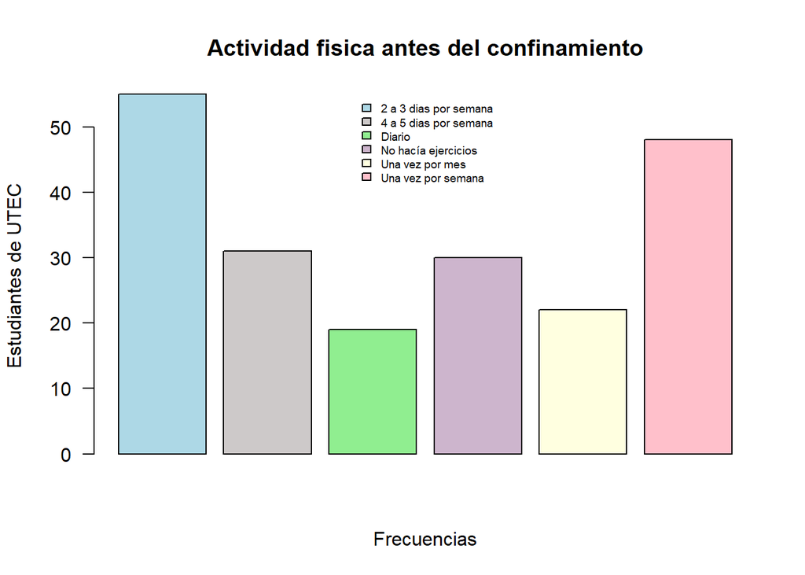

```r
counts <- table(BD$`Frecuencia de práctica de actividad física antes del confinamiento`)
barplot(counts, main="Actividad fisica antes del confinamiento", xaxt = "n", xlab = "Frecuencias", ylab = "Estudiantes de UTEC",
        col=c("lightblue", "snow3","lightgreen","thistle3","lightyellow","pink"), las=2,cex.names = 0.6)
legend('top', legend=rownames(counts),bty='n',
       fill=c("lightblue", "snow3","lightgreen","thistle3","lightyellow","pink"),cex = 0.6)
```

##### De la gráfica reconocer que antes de la pandemia la mayor parte de estudiantes prácticaba actividades físicas antes del confinamiento 2 a 3 días por semana.

```r
cat('Número de observaciones:', nrow(BD),'\n')
```

```
## Número de observaciones: 205
```

```r
cat('Número de casos completos de la variable frecuencia de práctica de actividad física antes del confinamiento:', sum(complete.cases(BD$`Frecuencia de práctica de actividad física antes del confinamiento`)),'\n')
```

```
## Número de casos completos de la variable frecuencia de práctica de actividad física antes del confinamiento: 205
```

##### El número de observaciones es 205 y el número de casos completos de la variable frecuencia de práctica de actividad física antes del confinamiento; por ello, la muestra selectiva para el análisis de esta variable es 205 observaciones.

```r
cat('Moda de la variable frecuencia de práctica de actividad física antes del confinamiento`', "2 a 3 días por semana" ,'\n')
```

```
## Moda de la variable frecuencia de práctica de actividad física antes del confinamiento` 2 a 3 días por semana
```

##### De lo determinado se puede mencionar que la frecuencia de práctica de actividad física antes del confinamiento mas frecuente fue 2 a 3 días, esto se ampliará mas luego del análisis de la frecuencia de práctica de actividad física después del confinamiento:

### - *Frecuencia de práctica de actividad física después del confinamiento*

### **Análisis univariado:**

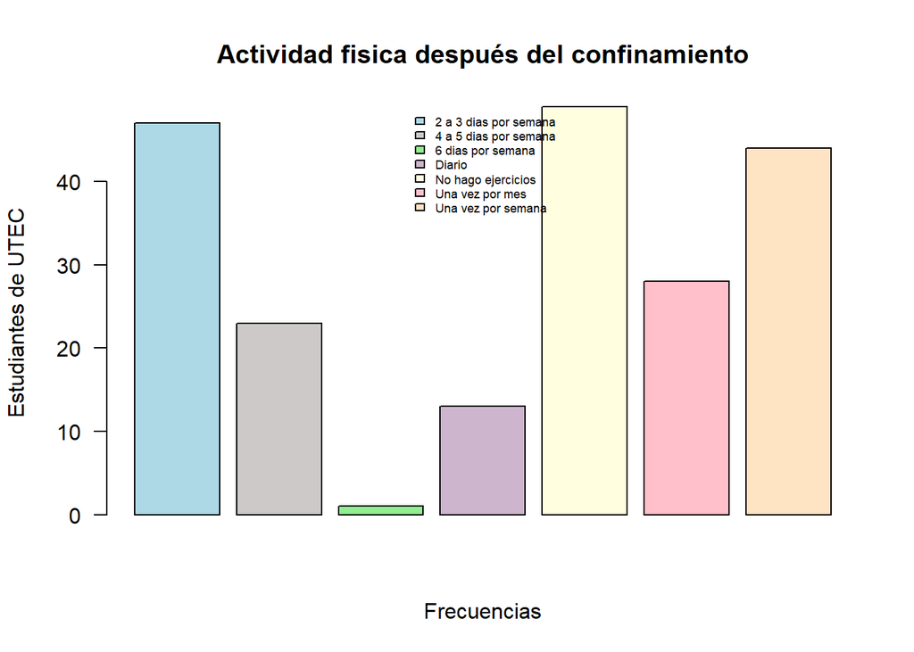

```r
counts <- table(BD$`Frecuencia de práctica de actividad física después del confinamiento`)
barplot(counts, main="Actividad fisica después del confinamiento",xaxt='n', xlab = "Frecuencias", ylab = "Estudiantes de UTEC",
        col=c("lightblue", "snow3","lightgreen","thistle3","lightyellow","pink", "bisque"), las=2,cex.names=0.45)
legend('top', legend=rownames(counts),bty='n',
       fill=c("lightblue", "snow3","lightgreen","thistle3","lightyellow","pink", "bisque"),cex = 0.55)
```

##### Del gráfico de barras obtenido se puede afirmar que después de la pandemia los estudiantes de UTEC no hace ejercicios, aunque una parte de ells lo hace 2 a 3 días o una vez por semana.

```r
cat('Número de observacione:', nrow(BD),'\n')
```

```
## Número de observacione: 205
```

```r
cat('Número de casos completos de la variable frecuencia de práctica de actividad física después del confinamiento:', sum(complete.cases(BD$`Frecuencia de práctica de actividad física después del confinamiento`)),'\n')
```

```
## Número de casos completos de la variable frecuencia de práctica de actividad física después del confinamiento: 205
```

##### El número de observaciones es 205 y el número de casos completos de la variable frecuencia de práctica de actividad física antes del confinamiento; por ello, la muestra selectiva para el análisis de esta variable es 205 observaciones.

```r
cat('Moda de la variable frecuencia de práctica de actividad física después del confinamiento:', "No hago ejercicios" ,'\n')
```

```
## Moda de la variable frecuencia de práctica de actividad física después del confinamiento: No hago ejercicios
```

##### Con la moda obtenida, es decir, la frecuencia mas frecuente podemos señalar que después del confinamiento los estudiantes no realizaban actividad física.

### **Análisis comparativo**

##### Al comparar los resultados obtenidos de la frecuencia mas común relacionado con la frecuencia antes y después del confinamiento se puede observar que hubo cambio ya que antes del confinamiento gran parte de los estudiantes de UTEC realizaba ejercicio de 2 a 3 veces por semana y después de la frecuencia, ya no realiza ejercicios. Probablemente sea porque durante el confinamiento había disponibilidad de tiempo.

### - *Percepción sobre la alimentación actual:*

### **Análisis univariado:**

##### En esta variable se analizo la percepcion actual de los habitos alimenticios saludables en los estudiantes de UTEC, donde se obtuvo los siguientes resultados:

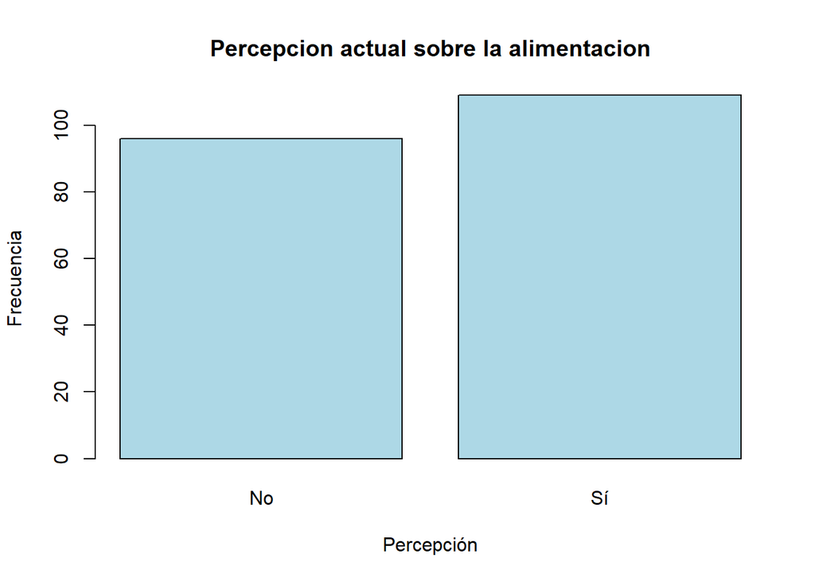

```r
counts <- table(BD$`Percepcion sobre su alimentación actual`)
barplot(counts, main="Percepcion actual sobre la alimentacion",  xlab = "Percepción", ylab = "Frecuencia",
        col=c( "lightblue"))
```

```r
cat('Número de observaciones de la variable percepcion de la alimentacion actual:', nrow(BD),'\n')
```

```
## Número de observaciones de la variable percepcion de la alimentacion actual: 205
```

```r
cat('Número de casos completos de la variable percepcion de la alimentacion actual:', sum(complete.cases(BD$`Percepcion sobre su alimentación actual`)),'\n')
```

```
## Número de casos completos de la variable percepcion de la alimentacion actual: 205
```

##### El número de observaciones y el numero de casos completos para la variable percepcion de la alimentacion actual es 205 por lo que la muestra selectiva para el análisis de esta variable es 205 observaciones.

```r
cat('Moda de la variable percepcion de la alimentacion actual:', "Si" ,'\n')
```

```
## Moda de la variable percepcion de la alimentacion actual: Si
```

##### Esta variable es de tipo cualitativa por lo que se determina la moda obteniendose que una gran parte de los estudiantes de la Universidad de Ingenieria y Tecnologia considera que tienen una alimentacion saludable, por lo que se podría deducir que tiene hábitos de alimentación saludable.

### - *Veces de consumo de alimentos por día*

### **Análisis univariado:**

##### En esta variable se evaluo el impacto durante el confinamiento en la frecuencia del consumo de alimentos por dia en los estudiantes de UTEC, a continuación se analiza la frecuencia donde se obtuvo los siguientes resultados:

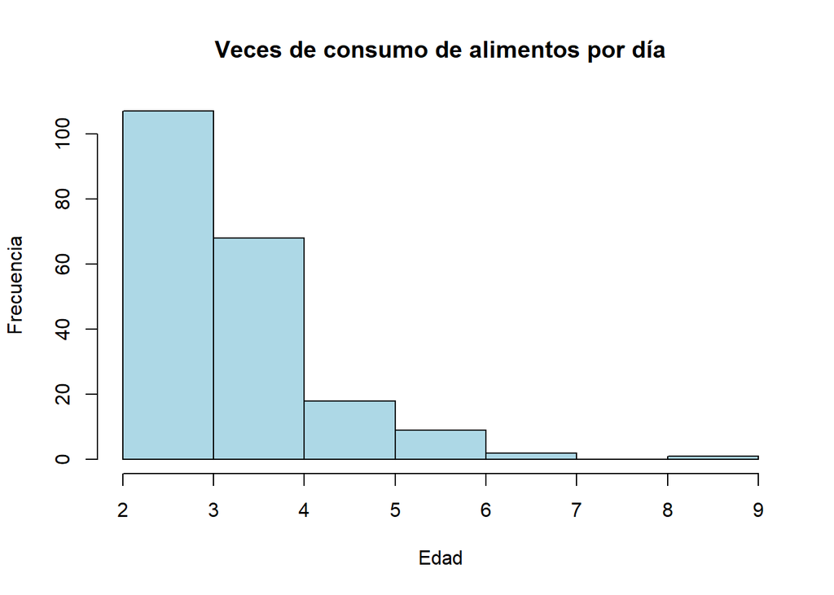

```r
hist(x = BD$`Veces de consumo de alimentos por día`, main = "Veces de consumo de alimentos por día", xlab = "Edad", ylab = "Frecuencia", col = "lightblue")
```

##### Del gráfico de barras obtenido podemos mencionar que existen dos tendencias respecto a las veces de consumo de alimentos por día donde encabeza 3 veces y le sigue 4 veces de consumo de alimentos por día.

### **Descriptores numéricos:**

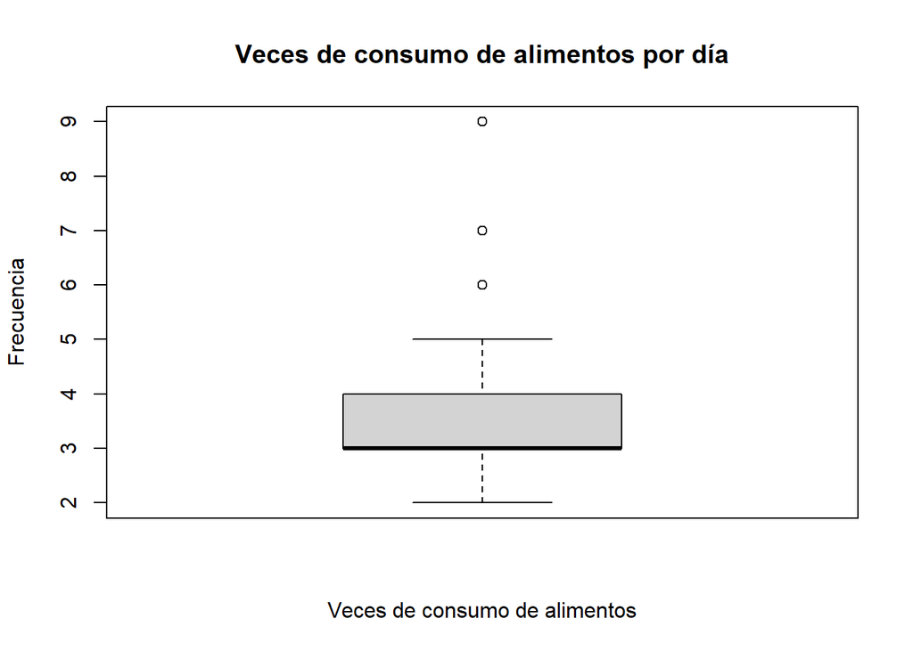

```r
boxplot(BD$`Veces de consumo de alimentos por día`, main = "Veces de consumo de alimentos por día", xlab= "Veces de consumo de alimentos", ylab= "Frecuencia")
```

##### De este grafico podemos afirmar que durante el periodo de confinamiento, los estudiantes de la Universidad de Ingenieria y Tecnologia generalmente consumen alrededor de 3 porciones de alimentos al dia. Asi mismo posee datos atipicos, por lo que es viable ya que existiran alumnos que tendran distintos tipos de alimentacion segun su estilo de vida.

```r
cat('Numero de observaciones de la variable Veces de consumo de alimentos por día:', nrow(BD),'\n')
```

```
## Numero de observaciones de la variable Veces de consumo de alimentos por día: 205
```

```r
cat('Numero de casos completos:', sum(complete.cases(BD$`Veces de consumo de alimentos por día`)))
```

```
## Numero de casos completos: 205
```

##### Vemos que el numero de observaciones y casos completos es 205. Por lo que la muestra seleccionada para el analisis de la variable es 205 observaciones.

```r
cat('Mediana de la variable de veces consumo de alimentos por día es:', median(BD$`Veces de consumo de alimentos por día`),'\n')
```

```
## Mediana de la variable de veces consumo de alimentos por día es: 3
```

```r
cat('Moda de la variable de veces de consumo de alimentos por dia:',3, '\n')
```

```
## Moda de la variable de veces de consumo de alimentos por dia: 3
```

```r
cat('Varianza de la variable de veces de consumo de alimentos por dia',round(var(BD$`Veces de consumo de alimentos por día`,na.rm=TRUE),2),'\n')
```

```
## Varianza de la variable de veces de consumo de alimentos por dia 1.17
```

```r
cat('Desviacion estandar de la variable de veces consumo de alimentos por dia:',round(sd(BD$`Veces de consumo de alimentos por día`,na.rm=TRUE),2),'\n')
```

```
## Desviacion estandar de la variable de veces consumo de alimentos por dia: 1.08
```

```r
cat('Coeficiente de variacion de la variable de veces consumo de alimentos por dia:',round((sd(BD$`Veces de consumo de alimentos por día`,na.rm=TRUE)/mean(BD$`Veces de consumo de alimentos por día`,na.rm=TRUE))*100,2),'\n')
```

```
## Coeficiente de variacion de la variable de veces consumo de alimentos por dia: 30.13
```

##### A partir de lo realizado podemos deducir que los estudiantes de la Universidad de Ingenieria Y Tecnologia consume en promedio alrededor de 3 a 4 veces de porciones al dia. La cantidad que mas se repite entre los estudiantes es de 3 veces al dia. Asimismo, podemos ver que existe un considerable coeficiente de variacion, que supera los 15% por lo que los datos son heterogéneos y existe variabilidad entre ellos.

### - *Omisión de comidas por día:*

### **Análisis univariado:**

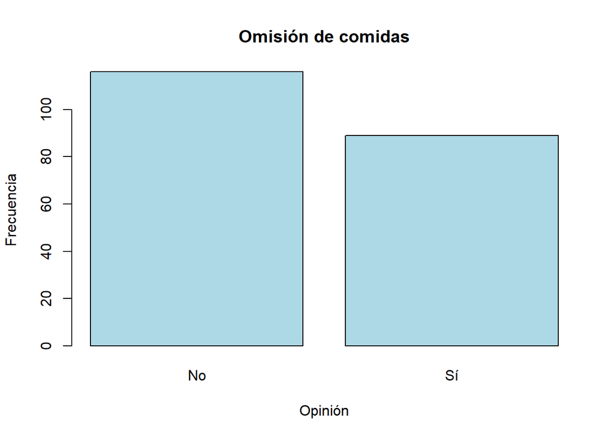

```r
TABLA<-table(BD$`Omisión de comidas`)
barplot(TABLA, main = "Omisión de comidas",
     xlab = "Opinión", ylab = "Frecuencia",
     col = c("lightblue"))
```

##### A partir de este gráfico de barras podemos determinar que una parte los estudiantes de UTEC no suelen saltarse las comidas por lo que se podría decir que tienen un estilo de vida saludable, sin embargo la diferencia no es muy significativa ya que solo es de un 13.17%. ### **Descriptores numéricos**

```r
cat('Número de observaciones:', nrow(BD),'\n')
```

```
## Número de observaciones: 205
```

```r
cat('Número de casos completos de la variable omisión de comidas por día:', sum(complete.cases(BD$`Omisión de comidas`)),'\n')
```

```
## Número de casos completos de la variable omisión de comidas por día: 205
```

##### El número de observaciones es 205 y el número de casos completos de la variable somisión de comidas por día, por lo que la muestra selectiva para el análisis de esta variable es 205 observaciones.

```r
cat('Moda de la variable omisión de comidas por día:', "No" ,'\n')
```

```
## Moda de la variable omisión de comidas por día: No
```

##### De lo determinado se puede mencionar que la opinión mas frecuente respecto a la pregunta que busca averiguar si los estudiante de UTEC se saltan las comidas es no, es decir, de nuestra muestra en su mayoria los estudiantes de UTEC no suelen saltarse la comida. A continuación determinamos en porcentajes los resultados de esta variable:

```r
cat('% de estudiantes de UTEC que consideran que no se saltan las comidas:', round((116*100)/sum(table(BD$`Omisión de comidas`))), '\n')
```

```
## % de estudiantes de UTEC que consideran que no se saltan las comidas: 57
```

```r
cat('% de estudiantes de UTEC que consideran que se saltan las comidas:', round((89*100)/sum(table(BD$`Omisión de comidas`))),'\n')
```

```
## % de estudiantes de UTEC que consideran que se saltan las comidas: 43
```

##### De lo realizado se menciona que mas de la mitad de estudiantes de la Universidad de Ingeniería y Tecnología mencionaron que no se saltaban las comidas durante el día, por lo que podemos determinar que el tipo de alimentación actual de ellos es saludable, ya que si una persona omite las comidas durante el día, no tiene un estilo de alimentación saludable por el inequilibrio en sus horarios.

### **Análisis probabilístico**

#### - Probabilidades Frecuentistas

##### En las siguientes tablas se emplearon tres variables la primera es la “Percepción sobre el cambio de alimentación por el confinamiento”, la segunda es el “Lugar de residencia” y la tercera “Veces de consumo de alimentos por día”. Según indica Emily Manoogian, investigadora clínica del Instituto Salk sobre Estudios Biológicos (California, Estados Unidos) indica que los jóvenes deben tener un habito alimenticio recomendable basado en tres comidas al día. A través de las siguientes tablas se evaluará probabilidades con cada una de estas variables.

#### TABLA 1

```r
crosstab(BD$`Lugar de residencia`,BD$`Percepción sobre el cambio de alimentación por el confinamiento`,plot=FALSE)
```

```
##    Cell Contents
## |-------------------------|
## |                   Count |
## |-------------------------|
##
## =============================================
##                             BD$`Percepción sobre el cambio de alimentación por el confinamiento`
## BD$`Lugar de residencia`     No    Sí   Total
## ---------------------------------------------
## Central                       5    17      22
## ---------------------------------------------
## Central Sur                  12    45      57
## ---------------------------------------------
## Este                          7    33      40
## ---------------------------------------------
## Norte                         7    24      31
## ---------------------------------------------
## Provincia                     4    33      37
## ---------------------------------------------
## Sur                           8    10      18
## ---------------------------------------------
## Total                        43   162     205
## =============================================
```

##### $P(N ∩ L2)$

##### $P(N ∩ L2)=12/205$

##### $P(N ∩ L2)=0.05853659$

```r
#P(N ∩ L2)=12/205
12/205
```

```
## [1] 0.05853659
```

##### $P(N^c ∩ L5^c )$

##### $P(N^c ∩ L5^c )= P(N ∪ L5)^c$

##### $P(N^c ∩ L5^c )= 1 - P(N ∪ L5)$

##### $P(N^c ∩ L5^c )= 1 - (43/205+37/205- 4/205)$

##### $P(N^c ∩ L5^c )=0.6292683$

```r
#P(N^c ∩ L5^c)
1- (43/205+37/205- 4/205)
```

```
## [1] 0.6292683
```

##### 3-¿Cuál es la probabilidad de un estudiante que es de provincia y no haya cambiado su alimentación?

##### $P(L5 ∩ N)$

##### $P(L5 ∩ N)=4/205$

##### $P(L5 ∩ N)= 0.0195122$

```r
4/205
```

```
## [1] 0.0195122
```

##### La probabilidad de un estudiante que es de provincia y no haya cambiado su alimentación es de 0.0195122.

##### 4-Si se sabe que el estudiante es de Lima Sur,¿Cuál es la probabilidad que haya cambiado su alimentación por el confinamiento?

##### $P(S/L6)$

##### $P(S/L6)=P(S ∩ L6)/P(L6)$

##### $P(S/L6)=(10/205)/(18/205)$

##### $P(S/L6)=0.5555556$

```r
#P(S/L6)
(10/205)/(18/205)
```

```
## [1] 0.5555556
```

##### La probabilidad que un estudiante que reside en Lima Sur ha cambiado su alimentación por el confinamiento es 0.5555556.

##### 5-¿Cuál es la probabilidad que el estudiante haya cambiado su alimentación pero no sea de Lima norte?

##### $P(S ∩ L4^c )$

##### $P(S ∩ L4^c )= P(S) - P(S ∩ L4)$

##### $P(S ∩ L4^c )= 162/205 -(24/205)$

##### $P(S ∩ L4^c )= 0.6731707$

```r
#P(S ∩ L4^c )
162/205 -(24/205)
```

```
## [1] 0.6731707
```

##### La probabilidad que el estudiante haya cambiado su alimentación pero no sea de Lima norte es de 0.6731707.

##### 6-¿Cuál es la probabilidad que el estudiante no sea de Lima Este, o no haya cambiado su alimentación por el confinamiento?

##### $P(L3^c ∪ S^c)$

##### $P(L3^c ∪ S^c)=P(L3 ∩ S)^c$

##### $P(L3^c ∪ S^c)=1 - P(L3 ∩ S)$

##### $P(L3^c ∪ S^c)=1 -(33/205)$

##### $P(L3^c ∪ S^c)=0.8390244$

```r
#P(L3^c U S^c)
1 -(33/205)
```

```
## [1] 0.8390244
```

##### La probabilidad que un estudiante no sea de Lima Este o no haya cambiado su alimentación por el confinamiento es de 0.8390244.

##### 7-¿Cuál es la probabilidad que un estudiante haya cambiado su alimentación?

##### $P(S)$

##### $P(S)=162/205$

##### $P(S)=0.7902439$

```r
#P(S)
162/205
```

```
## [1] 0.7902439
```

##### La probabilidad que un estudiante haya cambiado su alimentación por el confinamiento es de 0.7902439.

##### 8-¿Cuál es la probabilidad que un estudiante no haya cambiado su alimentación?

##### $P(N)$

##### $P(N)=43/205$

##### $P(N)=0.2097561$

```r
#P(N)
43/205
```

```
## [1] 0.2097561
```

##### La probabilidad que un estudiante no haya cambiado su alimentación es de 0.2097561.

## - TABLA 2

```r
crosstab(BD$`Veces de consumo de alimentos por día`,BD$`Percepción sobre el cambio de alimentación por el confinamiento`,plot=FALSE)
```

```
##    Cell Contents
## |-------------------------|
## |                   Count |
## |-------------------------|
##
## ===============================================================
##                                               BD$`Percepción sobre el cambio de alimentación por el confinamiento`
## BD$`Veces de consumo de alimentos por día`     No    Sí   Total
## ---------------------------------------------------------------
## 2                                               1    22      23
## ---------------------------------------------------------------
## 3                                              29    55      84
## ---------------------------------------------------------------
## 4                                              10    58      68
## ---------------------------------------------------------------
## 5                                               2    16      18
## ---------------------------------------------------------------
## 6                                               0     9       9
## ---------------------------------------------------------------
## 7                                               1     1       2
## ---------------------------------------------------------------
## 9                                               0     1       1
## ---------------------------------------------------------------
## Total                                          43   162     205
## ===============================================================
```

##### N: Alimentación no cambió por el confinamiento

##### S: Alimentación si cambió por el confinamiento

##### C2: Consumo de alimentos 2 veces por día

##### C3: Consumo de alimentos 3 veces por día

##### C4: Consumo de alimentos 4 veces por día

##### C5: Consumo de alimentos 5 veces por día

##### C6: Consumo de alimentos 6 veces por día

##### C7: Consumo de alimentos 7 veces por día

##### C9: Consumo de alimentos 9 veces por día

##### 1-¿Cuál es la probabilidad que un estudiante consuma alimentos más de 3 veces al día y opine que no ha cambiado su alimentación por el confinamiento?

##### $P((C4 ∪ C5 ∪ C6 ∪ C7 ∪ C9) ∩ N)$

##### $P((C4 ∪ C5 ∪ C6 ∪ C7 ∪ C9) ∩ N)=(10 + 2 + 0+ 1+ 0)/205$

##### $P((C4 ∪ C5 ∪ C6 ∪ C7 ∪ C9) ∩ N)=0.06341463$

```r
#P((C4 U C5 U C6 U C7 U C9) ∩ N)
(10+2 + 0+ 1+ 0)/205
```

```
## [1] 0.06341463
```

##### La probabilidad que un estudiante consuma alimentos más de 3 veces al día y a la vez opine que su alimentación no haya cambiado por el confinamiento es de 0.06341463.

##### 2-Sabiendo que un estudiante indica que consume alimentos 3 veces al día ,¿Cuál es la probabilidad que su alimentación por el confinamiento no haya cambiado?

##### $P(N/C3)$

##### $P(N/C3)=P(N ∩ C3)/P(C3)$

##### $P(N/C3)=(29/205)/(84/205)$

##### $P(N/C3)=0.3452381$

```r
#P(N/C3)
(29/205)/(84/205)
```

```
## [1] 0.3452381
```

##### La probabilidad de un estudiante que no haya cambiado su alimentación sabiendo que consume alimentos 3 veces al día es de 0.3452381.

##### 3-¿Cuál es la probabilidad que un estudiante que consuma alimentos 2 veces al día haya cambiado su alimentación?

##### $P(C2 ∩ S)$

##### $P(C2 ∩ S)=22/205$

##### $P(C2 ∩ S)=0.1073171$

```r
#P(C2 ∩ S)
22/205
```

```
## [1] 0.1073171
```

##### La probabilidad que un estudiante consuma alimentos 2 veces al día haya cambiado su alimentación es de 0.1073171.

##### 4-¿Cuál es la probabilidad que un estudiante que no consume alimentos 3 veces al día no haya cambiado su alimentación?

##### $P(C3^c ∩ N )$

##### $P(C3^c ∩ N )= P(N)-P(C3 ∩ N)$

##### $P(C3^c ∩ N )=43/205 -29/205$

##### $P(C3^c ∩ N )=0.06829268$

```r
#P(C3^c ∩ N )
43/205 -29/205
```

```
## [1] 0.06829268
```

##### La probabilidad de un estudiante que no consume akimentos 3 veces al día y no haya cambiado su alimentación es de 0.06829268.

##### 5-Sabiendo que un estudiante indica que consume alimentos 2 veces al día ,¿Cuál es la probabilidad que su alimentación por el confinamiento haya cambiado?

##### $P(S/C2)$

##### $P(S/C2)=P(S ∩ C2)/P(C2)$

##### $P(S/C2)=(22/205)/(23/205)$

##### $P(S/C2)=0.9565217$

```r
#P(S/C2)
(22/205)/(23/205)
```

```
## [1] 0.9565217
```

##### La probabilidad de un estudiante que haya cambiado su alimentación por el confinamiento sabiendo que consume alimentos 2 veces al día es de 0.9565217.

#### **RESULTADOS:**

##### - Se obtuvo que la probabilidad de encontrar a una persona sabiendo que tiene una alimentación saludable consumiendo 3 comidas al día no haya cambiado su alimentación por el confinamiento es de 0.3452381.

## - Modelos probabilisticos

##### Objetivos propuestos:

##### Algunas de las variables presentes en nuestro proyecto se encuentran relacionadas y funcionan únicamente en pares, mientras que otras se encuentran independientes al resto y varían en su propia categoría. Para estas variables independientes se propuso 3 objetivos propuestos con los que buscamos analizar la posibilidad de ocurrencia de estos eventos con la teoría probabilista estudiada en clase:

##### - Distribución Binomial

##### *OBJETIVO:* Determinar la probabilidad de que más de 50 estudiantes de UTEC perciban cambios en su alimentación dentro de un grupo de 100 encuestados.

```r
table(BD$`Percepcion sobre su alimentación actual`)
```

```
##
##  No  Sí
##  96 109
```

```r
cat('Probabilidad (1 - pbnimon(x, n, p)):', 1-pbinom(50,100,96/205),'\n')
```

```
## Probabilidad (1 - pbnimon(x, n, p)): 0.2307682
```

```r
cat('Valor esperado (E(X)=n*p):', 100*(96/205),'\n')
```

```
## Valor esperado (E(X)=n*p): 46.82927
```

```r
cat('Varianza (V(x)=n*p*q):', 100*(96/205)*(1-(96/205)),'\n')# Donde q = 1 - p  (Probabilidad de fracaso)
```

```
## Varianza (V(x)=n*p*q): 24.89946
```

```r
cat('Desviación estándar (D(x)=(n*p*q)^0.5):', (100*(96/205)*(1-96/205))^0.5,'\n')
```

```
## Desviación estándar (D(x)=(n*p*q)^0.5): 4.989936
```

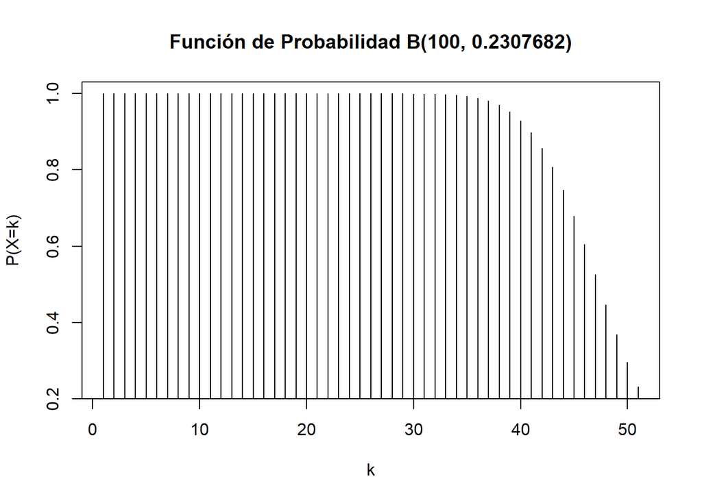

```r
plot(1 - pbinom(0:50,100,96/205),type="h",xlab="k",ylab="P(X=k)",main="Función de Probabilidad B(100, 0.2307682)")
```

##### - Distribución Binomial Negativa

##### *OBJETIVO:* Determinar la probabilidad de que en 50 entrevistados se encuentre el 50% del numero de entrevistados con veces de consumo de alimentos mayor a 5 por día.

##### *2. Variable “Veces de consumo de alimentos por día”:* Analizando la data se conoce que del total de entrevistados(205), el número de entrevistados con veces de consumo de alimentos mayor a 5 por día es igual a 12. Con este modelo probabilista se buscará hallar la probabilidad de que en 50 entrevistados se encuentre el 50% del numero de entrevistados con veces de consumo de alimentos mayor a 5 por día (6). Además, buscaremos hallar el valor esperado de nuestra función probabilidad, su varianza y su desviación estándar

##### P(x = 50), k=6, p = 12/205

```r
table(BD$`Veces de consumo de alimentos por día`)
```

```
##
##  2  3  4  5  6  7  9
## 23 84 68 18  9  2  1
```

```r
cat('Probabilidad (dnbinom(x − k, k, p)):', dnbinom(44,6,12/205),'\n')
```

```
## Probabilidad (dnbinom(x - k, k, p)): 0.005398092
```

```r
cat('Valor esperado (μ = k/p):', 6/(12/205),'\n')
```

```
## Valor esperado (µ = k/p): 102.5
```

```r
cat('Varianza (V(x)=k(1 − p)/p^2):', 6*(1-12/205)/(12/205)^2,'\n')
```

```
## Varianza (V(x)=k(1 - p)/p^2): 1648.542
```

```r
cat('Desviación estándar (D(x)=(k(1 − p)/p^2)^0.5:', (6*(1-12/205)/(12/205)^2)^0.5 ,'\n')
```

```
## Desviación estándar (D(x)=(k(1 - p)/p^2)^0.5: 40.60224
```

##### Esta es la gráfica de nuestra función probabilidad binomial negativa

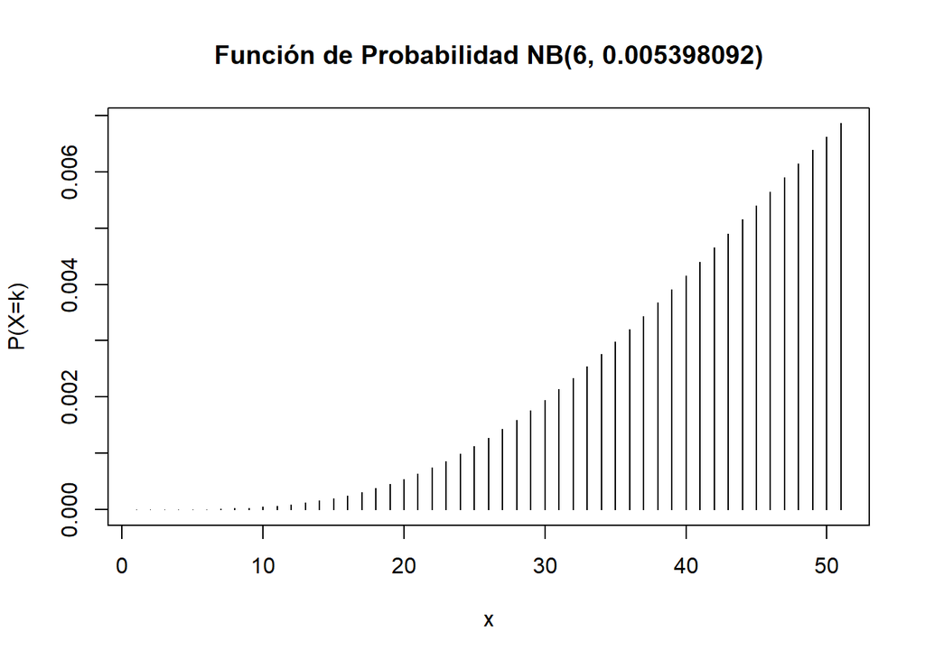

```r
plot(dnbinom(0:50,6,12/205),type="h",xlab="x",ylab="P(X=k)",main="Función de Probabilidad NB(6, 0.005398092)")
```

##### RESULTADOS:

##### El uso de este modelo es debido a que según la teoría de la distribución binomial negativa, se desea obtener 6 de los 12 éxitos posibles dentro del muestreo con un numero de ensayos igual a 50. La probabilidad es de un evento simple, por lo que se encuentra en base a la división de los números de casos favorables entre el numero de eventos posibles(12/205). Se determinó que la probabilidad que en 50 entrevistados se encuentre el 50% del numero de entrevistados con veces de consumo de alimentos mayor a 5 por día es 0.005398092. Asimismo, el valor esperado respecto a esta es 102.5 con una varianza de 1648.542 y desviación estándar 40.60224.

##### - Distribución Hipergeométrica:

##### *OBJETIVO:* Determinar la probabilidad de que dentro de una muestra aleatoria de 100 entrevistados, se encuentre como máximo 10 entrevistados de los cuales no se alteró su alimentación.

##### *3. Variable “Percepción sobre el cambio de alimentación por el confinamiento”:* También se conoce que solo 43 de los 205 entrevistados no percibieron ningún cambio en su alimentación durante el confinamiento. Se buscará hallar la probabilidad de que dentro de una muestra aleatoria de 100 entrevistados, se encuentre como máximo 10 entrevistados de los cuales no se alteró su alimentación. Además de esto, buscaremos hallar el valor esperado de nuestra función probabilidad, su varianza y su desviación estándar.

##### P(x ≤ 10), N = 205, M = 43, n=100

```r
table(BD$`Percepción sobre el cambio de alimentación por el confinamiento`)
```

```
##
##  No  Sí
##  43 162
```

```r
cat('Probabilidad (phyper(x, M, N − M, n)):', phyper(10,43,162,100),'\n')
```

```
## Probabilidad (phyper(x, M, N - M, n)): 0.0001239055
```

```r
cat('Valor esperado (E(X)= n*M/N):', 100*43/205,'\n')
```

```
## Valor esperado (E(X)= n*M/N): 20.97561
```

```r
cat('Varianza (V(X) = (n*M/N)(1 − M/N)(N-n)/(N-1)):', (100*(43/205))*(1-(43/205))*(205-100)/(205-1),'\n')
```

```
## Varianza (V(X) = (n*M/N)(1 - M/N)(N-n)/(N-1)): 8.531686
```

```r
cat('Desviación estándar (D(x)=((n*M/N)(1 − M/N)(N-n)/(N-1))^0.5:', ((100*(43/205))*(1-(43/205))*(205-100)/(205-1))^0.5,'\n')
```

```
## Desviación estándar (D(x)=((n*M/N)(1 - M/N)(N-n)/(N-1))^0.5: 2.920905
```

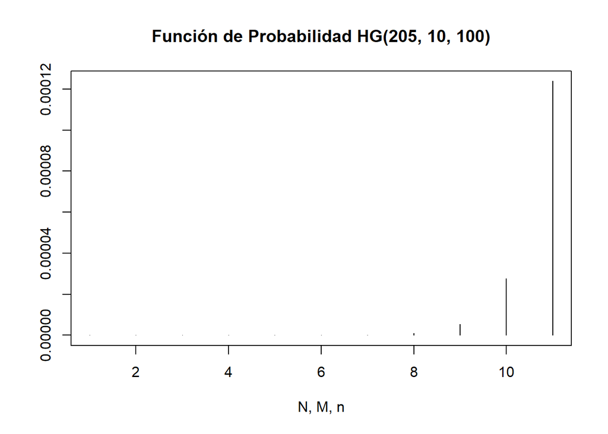

```r
plot(phyper(0:10,43,162,100),type="h",xlab="N, M, n",ylab="",main="Función de Probabilidad HG(205, 10, 100)")
```

### - **Bibliografía:**

##### - Restrepo, G. C. D., Soto, D. M. O., Borja, Y. U., Pérez, L. M. A., & Buján, M. V. S. (2020). Alimentación y nutrición durante la pandemia del COVID-19. Perspectivas En Nutrición Humana, September. https://www.researchgate.net/profile/Marco-Segura-Bujan/publication/344221675_Alimentacion_y_nutricion_durante_la_pandemia_del_COVID-19/links/5f5d6899a6fdcc11640ed7a7/Alimentacion-y-nutricion-durante-la-pandemia-del-COVID-19.pdf

##### - Tazeoğlu, A., Bozdogan, F. B. K., & Idiz, C. (2021). Evaluación de la conducta alimentaria de estudiantes universitarios durante el período de cuarentena durante el período pandémico de COVID-19: Comportamiento nutricional durante el período pandémico. Nutrición clínica y dietética hospitalaria, 41(2), 86-93. https://dialnet.unirioja.es/servlet/articulo?codigo=7952356

##### - Velázquez Hernández, J. (2020). Impacto de la pandemia SARS-COV2 en nuestros jóvenes. https://repositorio.lasalle.mx/handle/lasalle/1454